# Evaluation

Evaluating Information Retrieval and Machine Learning systems

## Outline

## Evaluation

- To know whether we can *trust* our method or system, we need to evaluate it.
- If you cannot measure it, you cannot improve it.
- Choose between different possible techniques in a data-driven way.
- Convince others that your work is meaningful
  - Peers, leadership, clients, yourself(!)
- Keep evaluating relentlessly, adapt to changes

## Designing IR/DM systems

- Just running your favourite algorithm is usually not a great way to start
- Consider the problem at large
  - Do you want to understand phenomena or do black box modelling?
  - How to define and measure success? Are there costs involved?
  - Do you have the right data? How can you make it better?
- Build prototypes early-on to evaluate the above.

## Designing IR/DM systems

- Analyse your model's mistakes
  - Should you collect more, or additional data?
  - Should the task be reformulated?
  - Often a higher payoff than endless finetuning
- Technical debt: creation-maintenance trade-off
  - Very complex machine learning systems are hard/impossible to put into practice
  - See 'Machine Learning: The High Interest Credit Card of Technical Debt'

[figure not shown]

### Real world evaluations

- Evaluate predictions, but also how outcomes improve *because of them*
- Feedback loops: predictions are fed into the inputs, e.g. as new data, invalidating models
- The signal your model found may just be an artifact of your biased data
  - See 'Why Should I Trust You?' by Marco Ribeiro et al.

[figure not shown]

- Adversarial situations (e.g. spam filtering) can subvert your predictions
- Do A/B testing (or bandit testing) to evaluate algorithms in the wild

### Levels of evaluation

- System-level: Response time, throughput, user retention,...
  - Time for indexing (nr. documents / hour)
  - Search time (latency as function of index size)
- Task-level: User *happiness*, satisfaction, understanding,...
  - Often subjective: novelty, required effort, presentation,...
  - Users find what they want quickly, return to search engine
  - Users find and buy products (e.g. time, percentage of users)
- Method-level: Correctness/effectiveness or predictions
  - Accuracy, precision, recall, ...
  - Cost functions

### Difficulties

- How to perform evaluation?
  - Benchmark documents, queries
  - Labelled data vs. user actions
- Are predictions *useful*?
  - Do users act on the results (e.g. click)
  - Do users need to modify the query?
  - Satisfactory / unsatisfactory termination
- Good proxy: are predictions *relevant*?
  - Do they address the 'information need'?
  - Need to consider user preferences, time, place,...

## Binary evaluation measures

- First, assume that we have labeled data (ground truth)
- We have positive (relevant) and a negative (irrelevant) predictions
- 2 different kind of errors:
  - False Positive (type I error): model predicts positive while the true label is negative
  - False Negative (type II error): model predicts negative while the true label is positive
- They are usually not equally important
  - Which side do you want to err on for a medical test? For a search engine?

#### Confusion matrices

- We can represent all predictions (correct and incorrect) in a confusion matrix
  - n by n array (n is the number of classes)
  - Rows correspond to true classes, columns to predicted classes
  - Each entry counts how often a sample that belongs to the class corresponding to the row was classified as the class corresponding to the column.
  - For binary classification, we label these true negative (TN), true positive (TP), false negative (FN), false positive (FP)

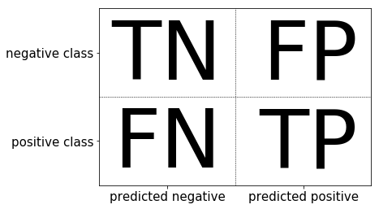

```python
mglearn.plots.plot_binary_confusion_matrix()
```

#### Predictive accuracy

- Accuracy is one of the measures we can compute based on the confusion matrix:

\begin{equation} \text{Accuracy} = \frac{\text{TP} + \text{TN}}{\text{TP} + \text{TN} + \text{FP} + \text{FN}} \end{equation}

- Almost never a good measure for information retrieval (or machine learning)

#### The problem with accuracy

- A search engine that returns very few results can have high accuracy
  - People want to find something, have high tolerance for junk
- Imbalanced data: Many more negatives than positives (or other way around)
  - e.g. credit card fraud, medical test for rare disease, web searches,...
  - Is a 99.99% accuracy good enough?
- Often does not distinguish between very different models
  - Are these three models really equally good?

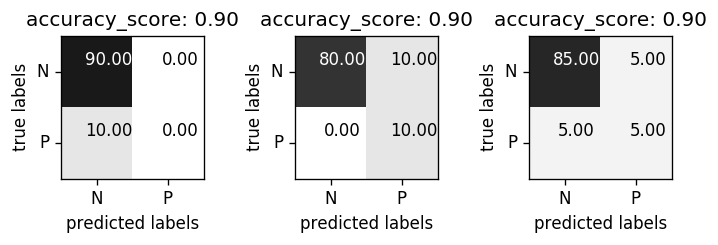

```python
plot_measure(accuracy_score)
```

**Precision** is used when the goal is to limit FPs

- Clinical trails: you only want to test drugs that really work
- Search engines: you want to avoid bad search results

\begin{equation} \text{Precision} = \frac{\text{TP}}{\text{TP} + \text{FP}} \end{equation}

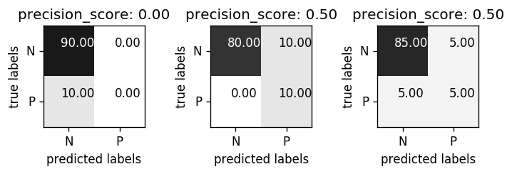

```python
from sklearn.metrics import precision_score
plot_measure(precision_score)
```

**Recall** is used when the goal is to limit FNs

- Cancer diagnosis: you don't want to miss a serious disease
- Search engines: You don't want to omit important hits
- Also know as sensitivity, hit rate, true positive rate (TPR)

\begin{equation} \text{Recall} = \frac{\text{TP}}{\text{TP} + \text{FN}} \end{equation}

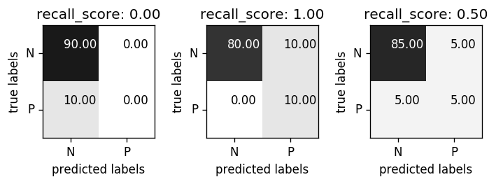

```python
from sklearn.metrics import recall_score
plot_measure(recall_score)
```

**Precision vs Recall**

[figure not shown]

- Arbitrarily high recall (but low precision) by returning almost all documents
- Arbitrarily high precision (but low recall) by returning almost no documents

### Precision-recall difficulties in IR

- Do not take number of irrelevant documents (TN) into account
- Assumes that the corpus (index) is large and complete
  - Recall: undefined when there are no relevant documents
  - Precision: undefined when nothing is retrieved
- Total number of relevant items (TP) can be unknown
  - Take a representative sample from the database
  - Take union of TPs from multiple retrieval techniques
- Needs human labelling (relevant/ not relevant)
- Binary assessment (not gradual)

**Fallout** of **FP rate**: take number of TN into account

- More systems-oriented: maximal recall, minimal fallout

\begin{equation} \text{Fallout} = \frac{\text{FP}}{\text{FP+TN}} \end{equation}

**F1-score** or *F1-measure*: trades off precision and recall

\begin{equation} \text{F1} = 2 \cdot \frac{\text{precision} \cdot \text{recall}}{\text{precision} + \text{recall}} \end{equation}

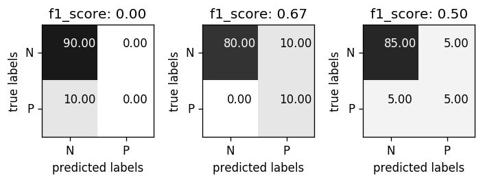

```python
from sklearn.metrics import f1_score
plot_measure(f1_score)
```

**E-measure** (parameterized F-measure) put emphasis on either precision and recall

\begin{equation} \text{E} = \frac{(1 + \beta^2) \cdot \text{precision} \cdot \text{recall}}{\beta^2 \cdot \text{precision} + \text{recall}} \end{equation}

**Classification measure Zoo**

[figure not shown]

https://en.wikipedia.org/wiki/Precision_and_recall"

## Taking uncertainty into account

- Many classifiers and retrieval techniques can return a probability per class
  - Based on a `decision_function` (threshold 0)
    - e.g. distance to decision boundary (SVM, linear models)
  - Based on probability (threshold 0.5)
    - Probabilistic (Bayesian) techniques
    - Others (e.g. voting in kNN or ensembling techniques)
- Threshold calibration
  - In some tasks, FP may be much worse than a FN
  - Choose threshold to get fewer FPs, more FNs

**Example**

- Avoid misclassifying a positive (red) point
- Points within decision boundary (black line) are classified positive
- Lowering the decision treshold (bottom figure): fewer FN, more FP

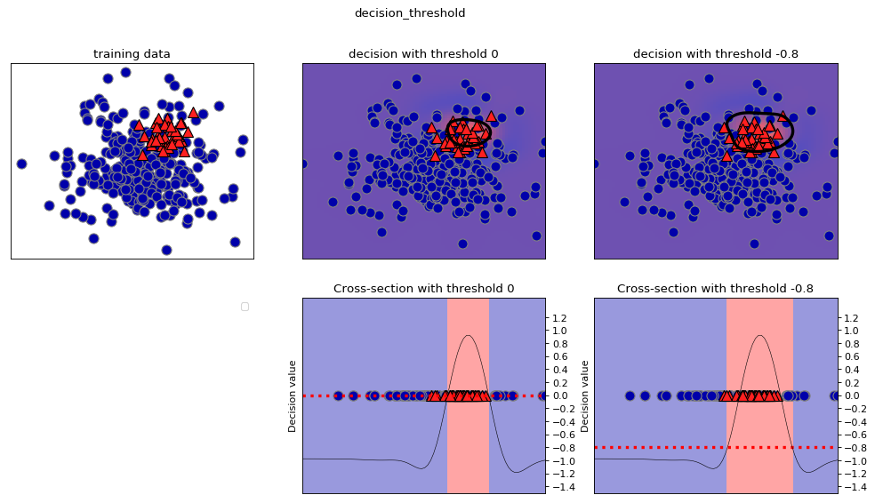

```python
plt.rcParams['figure.dpi'] = 80
mglearn.plots.plot_decision_threshold()
```

### Precision-Recall curves

- The best threshold depends on your application, should be driven by real-world goals.
- You can have arbitrary high recall, but you often want reasonable precision, too.
- It is not clear beforehand where the optimale trade-off (or *operating point*) will be, so it is useful to look at all possible thresholds
- Plotting precision against recall for all thresholds yields a **precision-recall curve**
  - Order predictions by decision function / probability / relevance score
  - Increase threshold gradually, plot all precision and recall values

**Example**

```python
df.iloc[:, 0:6]
```

|  | n | id | prediction | truth | recall | precision |
| --- | --- | --- | --- | --- | --- | --- |
| 0 | 1 | 588 | 0.90 | 1 | 1/6=0.167 | 1/1=1 |
| 1 | 1 | 589 | 0.88 | 1 | 2/6=0.333 | 2/2=1 |
| 2 | 1 | 576 | 0.85 | 0 | 2/6=0.333 | 2/3=0.667 |
| 3 | 1 | 590 | 0.84 | 1 | 3/6=0.5 | 3/4=0.75 |
| 4 | 1 | 986 | 0.82 | 0 | 3/6=0.5 | 3/5=0.6 |
| 5 | 1 | 592 | 0.79 | 1 | 4/6=0.667 | 4/6=0.667 |

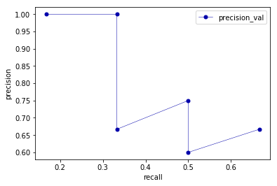

```python
ax = df.plot(x='recall_val', y='precision_val', marker='.', markersize=10)
ax.set_xlabel("recall");
ax.set_ylabel("precision");
```

- The default tradeoff (chosen by the `predict` method) is shown as *threshold zero*.
  - Higher threshold, more precision (move left)
  - Lower threshold, more recall (move right)
- The closer the curve stays to the upper-right corner, the better
- Calibration: it is possible to still get a precision of 0.5 with high recall

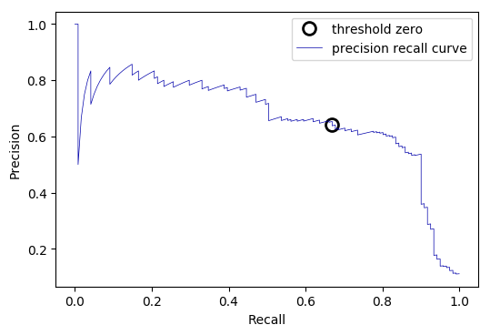

```python
# create a similar dataset as before, but with more samples
# to get a smoother curve
X, y = make_blobs(n_samples=(4000, 500), centers=2, cluster_std=[7.0, 2],
                  random_state=22)
X_train, X_test, y_train, y_test = train_test_split(X, y, random_state=0)

svc = SVC(gamma=.05).fit(X_train, y_train)

precision, recall, thresholds = precision_recall_curve(
    y_test, svc.decision_function(X_test))
# find threshold closest to zero:
close_zero = np.argmin(np.abs(thresholds))
plt.plot(recall[close_zero], precision[close_zero], 'o', markersize=10,
         label="threshold zero", fillstyle="none", c='k', mew=2)

plt.plot(recall, precision, label="precision recall curve")
plt.ylabel("Precision")
plt.xlabel("Recall")
plt.legend(loc="best");
```

#### Comparing models / systems

- Different techniques work best in different parts of the curve (at different operating points)
- RandomForest (in red) performs better at the extremes, SVM better in center
- The area under the precision-recall curve (AUPRC) is sometimes used as a general evaluation measure

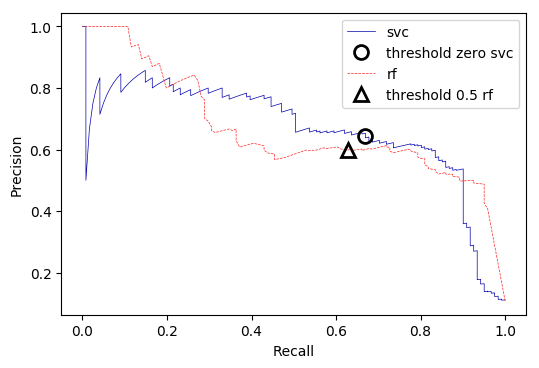

```python
from sklearn.ensemble import RandomForestClassifier

rf = RandomForestClassifier(n_estimators=100, random_state=0, max_features=2)
rf.fit(X_train, y_train)

# RandomForestClassifier has predict_proba, but not decision_function
# Only pass probabilities for the positive class
precision_rf, recall_rf, thresholds_rf = precision_recall_curve(
    y_test, rf.predict_proba(X_test)[:, 1])

plt.plot(recall, precision, label="svc")

plt.plot(recall[close_zero], precision[close_zero], 'o', markersize=10,
         label="threshold zero svc", fillstyle="none", c='k', mew=2)

plt.plot(recall_rf, precision_rf, label="rf")

close_default_rf = np.argmin(np.abs(thresholds_rf - 0.5))
plt.plot( recall_rf[close_default_rf], precision_rf[close_default_rf], '^', c='k',
         markersize=10, label="threshold 0.5 rf", fillstyle="none", mew=2)
plt.ylabel("Precision")
plt.xlabel("Recall")
plt.legend(loc="best");
```

### Precision-recall across queries

- Precision and recall are computed *per query*
- Compute average over a set of queries
- Take average precision-recall curve to calibrate thresholds
- Average precision at fixed recall level r
  - $N_q$ queries
  - $P_{i}(r)$: precision at recall level r for query i

\begin{equation} \overline{P}(r) = \sum_{i=1}^{N_q}\frac{P_{i}(r)}{N_q} \end{equation}

### Macro- vs Micro averaging

- Macro-averaging: compute average accross queries:
  - Use when you care about each query equally much
    $$\frac{\sum_{i=0}^{n}score_i}{n}$$
- Micro-averaging: compute total number of FP, FN, TP over all queries, then compute scores using these counts:
  - Use when you want to do equally well on hard queries
    $$recall = \frac{\sum_{i=0}^{n}TP_i}{\sum_{i=0}^{n}TP_i + \sum_{i=0}^{n}FN_i}$$

### Receiver Operating Characteristics (ROC) and AUC

- There is another trade-off between recall (true positive rate, TPR) and fallout (false positive rate, FPR).
- The 2D space created by TPR and FPR is called the Receiver Operating Characteristics (ROC) space
- A model will be at one point in this ROC space

\begin{equation} \text{TPR} = \frac{\text{TP}}{\text{TP} + \text{FN}} \end{equation}

\begin{equation} \text{FPR} = \frac{\text{FP}}{\text{FP} + \text{TN}} \end{equation}

- Varying the decision threshold yields the ROC curve
  - Lower threshold, more recall/TPR, move right
  - High threshold, fewer FPs, move left
- Ideal is close to the top left: high recall, low FPR
- Inspect the curve to find the preferred calibration
  - Here, we can get much higher recall with slightly worse FPR

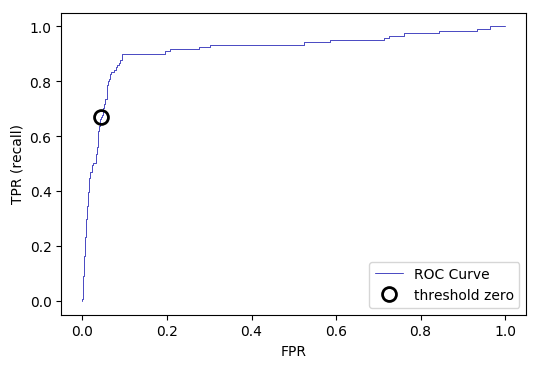

```python
plt.rcParams['savefig.dpi'] = 100 # Use 300 for PDF, 100 for slides
from sklearn.metrics import roc_curve
fpr, tpr, thresholds = roc_curve(y_test, svc.decision_function(X_test))

plt.plot(fpr, tpr, label="ROC Curve")
plt.xlabel("FPR")
plt.ylabel("TPR (recall)")
# find threshold closest to zero:
close_zero = np.argmin(np.abs(thresholds))
plt.plot(fpr[close_zero], tpr[close_zero], 'o', markersize=10,
         label="threshold zero", fillstyle="none", c='k', mew=2)
plt.legend(loc=4);
```

#### Visualization

- Consider distributions of all negative / positive points
- Hopefully, positive points have higher predicted relevance/probabilities
  - In random predictions the distributions would overlap.
- All points with a predicted probability higher than the threshold are predicted positive, others negative
- As we increase the threshold, we'll get fewer FPs, more FNs. We move from right to left along the ROC curve.

[figure not shown]

#### ROC Isometrics

- Different *costs* can be involved for FP and FN
- This yields different *isometrics* (lines of equal cost) in ROC space
- The optimal threshold is the point on the ROC curve where the cost in minimal
  - If a FP and FN are weigthed equally, cost lines follow the diagonal (blue line)
  - If a FP is 10 times worse than a FN: pink line
  - IF a FN is 10 times worse than a FP: red line

[figure not shown]

#### Model selection

- Again, we can compare multiple models by looking at the ROC curves
- We can calibrate the threshold depending on whether we need high recall or low FPR
- We can select between algorithms (or hyperparameters) depending on the involved costs.
- We can use the area under the ROC curve as an aggregated score

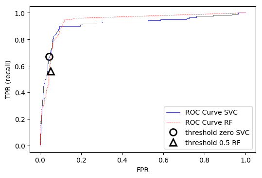

```python
from sklearn.metrics import roc_curve
fpr_rf, tpr_rf, thresholds_rf = roc_curve(y_test, rf.predict_proba(X_test)[:, 1])

plt.plot(fpr, tpr, label="ROC Curve SVC")
plt.plot(fpr_rf, tpr_rf, label="ROC Curve RF")

plt.xlabel("FPR")
plt.ylabel("TPR (recall)")
plt.plot(fpr[close_zero], tpr[close_zero], 'o', markersize=10,
         label="threshold zero SVC", fillstyle="none", c='k', mew=2)
close_default_rf = np.argmin(np.abs(thresholds_rf - 0.5))
plt.plot(fpr_rf[close_default_rf], tpr[close_default_rf], '^', markersize=10,
         label="threshold 0.5 RF", fillstyle="none", c='k', mew=2)

plt.legend(loc=4);
```

#### Imbalanced classes

- AUC is popular because it is insensitive to class imbalance
  - Random guessing always yields TPR=FPR
  - All points are on the diagonal line, hence an AUC of 0.5
- Example:
  - 3 models (SVM with different gamma values), ACC is the same, AUC not
  - If we optimize for ACC, our model could be just random guessing

```
gamma = 1.000  accuracy = 0.90  AUC = 0.5000
gamma = 0.100  accuracy = 0.90  AUC = 0.9582
gamma = 0.010  accuracy = 0.90  AUC = 0.9995
```

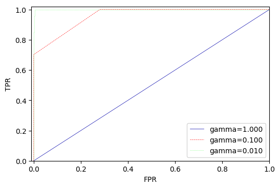

```python
from sklearn.datasets import load_digits

digits = load_digits()
y = digits.target == 9

X_train, X_test, y_train, y_test = train_test_split(
    digits.data, y, random_state=0)

plt.figure()

for gamma in [1, 0.1, 0.01]:
    svc = SVC(gamma=gamma).fit(X_train, y_train)
    accuracy = svc.score(X_test, y_test)
    auc = roc_auc_score(y_test, svc.decision_function(X_test))
    fpr, tpr, _ = roc_curve(y_test , svc.decision_function(X_test))
    print("gamma = {:.3f}  accuracy = {:.2f}  AUC = {:.4f}".format(
            gamma, accuracy, auc))
    plt.plot(fpr, tpr, label="gamma={:.3f}".format(gamma))
plt.xlabel("FPR")
plt.ylabel("TPR")
plt.xlim(-0.01, 1)
plt.ylim(0, 1.02)
plt.legend(loc="best");
```

### Rank-based measures

For ranked results (e.g. search engine)

- Precision@K: precision after K docs are seen (e.g. P@5 or P@10)
  - Users prefer relevant documents at the top
- R-precision: precision at position of last relevant document
- MAP (Mean Average Precision)
  - Mean of precisions at each relevant document
  - Use precision 0 if document not retrieved
- MRR (Mean Reciprocal Rank)
  - Per query, find location of first relevant document
  - When interested in 'first good answer'

### MAP: Example

[figure not shown]

- Average precision query 1: (1.0 + 0.67 + 0.5 + 0.44 + 0.5)/5 = 0.62
- Average precision query 2: (0.5 + 0.4 + 0.43)/3 = 0.44
- MAP: (0.62+0.44)/2 = 0.53

### Counting clicks: Interleaved ranking

- Compute rankings with different methods (red and blue)
- Interleave the two rankings (drop duplicates), count clicks
- Example: query for 'SVM'

[figure not shown]

### Interpreting clicks

- Clicking an item means that higher, non-clicked items are not relevant
  - Often user-specific (preference learning)
- Click prediction: build a click model that predicts whether a user will click the item
  - Use as additional signal to build final ranking (learning to rank)
- Visibility models:
  - Higher items receive more user attention
  - Can be measured via surveys, mouse/eye tracking

[figure not shown]

### Discounted Cumulative gain

- Assume that highly relevant docs are more useful than marginally relevant ones
- Assume that top-ranked relevant documents are more useful to the user
- *Gain* of examining document is discounted (e.g. by 1/log(rank))
- *Discounted Cumulative gain*: sum of document relevances weighted by discounted gain $$ DCG = r_1 + \frac{r_2}{log2(2)} + \frac{r_3}{log2(3)} + ... + \frac{r_n}{log2(n)} $$
- Normalized DCG: normalized across queries

### Designing IR/DM systems

- Use evaluations constantly to select/finetune techniques
  - Does removing or adding features help?
  - Does additional preprocessing help?
  - What are the best models and hyperparameters?
- Measure variance: difference in performance across queries
  - Often the variance across queries is much larger than variance across methods!

### Benchmarks

- To evaluate IR/DM systems, we often create a benchmark:
  - Set of standard documents and queries/topics
  - List of relevant documents for each queries
  - E.g. TREC collection
- Expert labels
- Naturally occurring labels:
  - Hashtags, emoticons,...
  - Clicks, bookmarks, downloads
  - ...

## A/B and bandit testing

- Test a single innovations
- Have most users use the old system, divert small group to new system
- Evaluate and compare performance
- Bandit testing: smaller time intervals, direct more users to currently winning system

[figure not shown]

### Multi-class classification

- Multiclass metrics are derived from binary metrics, averaged over all classes
- Example: handwritten digit recognition (10 classes)

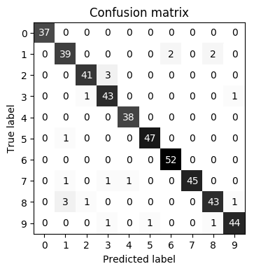

```python
scores_image = mglearn.tools.heatmap(
    confusion_matrix(y_test, pred), xlabel='Predicted label',
    ylabel='True label', xticklabels=digits.target_names,
    yticklabels=digits.target_names, cmap=plt.cm.gray_r, fmt="%d")
plt.title("Confusion matrix")
plt.gca().invert_yaxis()
```

Different ways to compute average

- macro-averaging: computes unweighted per-class scores: $\frac{\sum_{i=0}^{n}score_i}{n}$
  - Use when you care about each class equally much
- weighted averaging: scores are weighted by the relative size of the classes (support): $\frac{\sum_{i=0}^{n}score_i weight_i}{n}$
  - Use when data is imbalanced
- micro-averaging: computes total number of FP, FN, TP over all classes, then computes scores using these counts: $recall = \frac{\sum_{i=0}^{n}TP_i}{\sum_{i=0}^{n}TP_i + \sum_{i=0}^{n}FN_i}$
  - Use when you care about each sample equally much

## Regression metrics

Most commonly used are

- (root) mean squared error: $\frac{\sum_{i}(y_{pred_i}-y_{actual_i})^2}{n}$
- mean absolute error: $\frac{\sum_{i}|y_{pred_i}-y_{actual_i}|}{n}$
  - Less sensitive to outliers and large errors
- R squared (r2): $1 - \frac{\sum_{i}(y_{pred_i}-y_{actual_i})^2}{\sum_{i}(y_{mean}-y_{actual_i})^2}$
  - Ratio of variation explained by the model / total variation
  - Between 0 and 1, but *negative* if the model is worse than just predicting the mean
  - Easier to interpret (higher is better).
- R squared: 1 - ratio of $\sum_{i}(y_{pred_i}-y_{actual_i})^2$ (blue) and $\sum_{i}(y_{mean}-y_{actual_i})^2$ (red)

[figure not shown]

#### Visualizing errors

- Prediction plot (left): predicted vs actual target values
- Residual plot (right): residuals vs actual target values
  - Over- and underpredictions can be given different costs

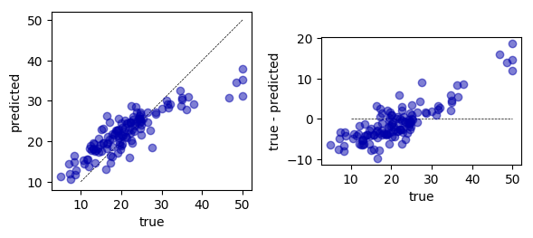

```python
from sklearn.linear_model import Ridge
from sklearn.datasets import load_boston
boston = load_boston()

X_train, X_test, y_train, y_test = train_test_split(boston.data, boston.target)

pred = Ridge(normalize=True).fit(X_train, y_train).predict(X_test)

plt.subplot(1, 2, 1)
plt.gca().set_aspect("equal")
plt.plot([10, 50], [10, 50], '--', c='k')
plt.plot(y_test, pred, 'o', alpha=.5)
plt.ylabel("predicted")
plt.xlabel("true");

plt.subplot(1, 2, 2)
plt.gca().set_aspect("equal")
plt.plot([10, 50], [0,0], '--', c='k')
plt.plot(y_test, y_test - pred, 'o', alpha=.5)
plt.xlabel("true")
plt.ylabel("true - predicted")
plt.tight_layout();
```

## Final thoughts

- Cost-sensitive classification
  - *Cost matrix*: a confusion matrix with a costs associated to every possible type of error
  - Some algorithms allow optimizing on these costs instead of their usual loss function
  - Meta-cost: builds ensemble of models by relabeling training sets to match a given cost matrix
    - Black-box: can make any algorithm cost sensitive (but slower and less accurate)

## More metrics

- There are many more metrics to choose from
  - Cohen's Kappa: accuracy, taking into account the possibility of predicting the right class by chance
    - 1: perfect prediction, 0: random prediction, negative: worse than random
    - With $p_0$ = accuracy, and $p_e$ = accuracy of random classifier: $$\kappa = \frac{p_o - p_e}{1 - p_e}$$
  - Balanced accuracy: accuracy where each sample is weighted according to the inverse prevalence of its true class
    - Identical to macro-averaged recall
  - Matthews correlation coefficient: another measure that can be used on imbalanced data
    - 1: perfect prediction, 0: random prediction, -1: inverse prediction $$MCC = \frac{tp \times tn - fp \times fn}{\sqrt{(tp + fp)(tp + fn)(tn + fp)(tn + fn)}}$$